# Project 1

## Step 1: Open the `sat_scores.csv` file. Investigate the data, and answer the questions below.

##### 1. What does the data describe?

##### 2. Does the data look complete? Are there any obvious issues with the observations?

##### 3. Create a data dictionary for the dataset.

## Step 2: Load the data.

##### 4. Load the data into a list of lists

```python
import csv
import numpy as np
import scipy
import scipy.stats as stats
import pylab as pl
import matplotlib.pyplot as plt
import plotly.plotly as py
import pandas as pd
import seaborn as sns
import plotly.graph_objs as go
sns.set_style('whitegrid')
%matplotlib inline
```

```python
sat_csv_path = '../assets/sat_scores.csv'
csv_list = []
with open(sat_csv_path, 'r') as f:
    for row in csv.reader(f):
        csv_list.append(row)
```

##### 5. Print the data

```python
csv_list
```

```
[['State', 'Rate', 'Verbal', 'Math'],
 ['CT', '82', '509', '510'],
 ['NJ', '81', '499', '513'],
 ['MA', '79', '511', '515'],
 ['NY', '77', '495', '505'],
 ['NH', '72', '520', '516'],
 ['RI', '71', '501', '499'],
 ['PA', '71', '500', '499'],
 ['VT', '69', '511', '506'],
 ['ME', '69', '506', '500'],
 ['VA', '68', '510', '501'],
 ['DE', '67', '501', '499'],
 ['MD', '65', '508', '510'],
 ['NC', '65', '493', '499'],
 ['GA', '63', '491', '489'],
 ['IN', '60', '499', '501'],
 ['SC', '57', '486', '488'],
 ['DC', '56', '482', '474'],
 ['OR', '55', '526', '526'],
 ['FL', '54', '498', '499'],
 ['WA', '53', '527', '527'],
 ['TX', '53', '493', '499'],
 ['HI', '52', '485', '515'],
 ['AK', '51', '514', '510'],
 ['CA', '51', '498', '517'],
 ['AZ', '34', '523', '525'],
 ['NV', '33', '509', '515'],
 ['CO', '31', '539', '542'],
 ['OH', '26', '534', '439'],
 ['MT', '23', '539', '539'],
 ['WV', '18', '527', '512'],
 ['ID', '17', '543', '542'],
 ['TN', '13', '562', '553'],
 ['NM', '13', '551', '542'],
 ['IL', '12', '576', '589'],
 ['KY', '12', '550', '550'],
 ['WY', '11', '547', '545'],
 ['MI', '11', '561', '572'],
 ['MN', '9', '580', '589'],
 ['KS', '9', '577', '580'],
 ['AL', '9', '559', '554'],
 ['NE', '8', '562', '568'],
 ['OK', '8', '567', '561'],
 ['MO', '8', '577', '577'],
 ['LA', '7', '564', '562'],
 ['WI', '6', '584', '596'],
 ['AR', '6', '562', '550'],
 ['UT', '5', '575', '570'],
 ['IA', '5', '593', '603'],
 ['SD', '4', '577', '582'],
 ['ND', '4', '592', '599'],
 ['MS', '4', '566', '551'],
 ['All', '45', '506', '514']]
```

##### 6. Extract a list of the labels from the data, and remove them from the data.

```python
labels_list= csv_list[0]
del csv_list[0], csv_list[-1]
len(csv_list)
```

```
51
```

##### 7. Create a list of State names extracted from the data. (Hint: use the list of labels to index on the State column)

```python
state_list = [row[0] for row in csv_list]
print state_list
```

[output not shown]

##### 8. Print the types of each column

```python
print [type(item) for item in csv_list[0]]
```

```
[<type 'str'>, <type 'str'>, <type 'str'>, <type 'str'>]
```

##### 9. Do any types need to be reassigned? If so, go ahead and do it.

```python
refined_csv_list = []
for row in csv_list:
    refined_csv_list.append([int(item) if item.isdigit() else item for item in row])
print refined_csv_list
```

[output not shown]

##### 10. Create a dictionary for each column mapping the State to its respective value for that column.

```python
rate_dic = {row[0]:row[1] for row in refined_csv_list}
math_dic = {row[0]:row[2] for row in refined_csv_list}
verbal_dic = {row[0]:row[3] for row in refined_csv_list}
```

##### 11. Create a dictionary with the values for each of the numeric columns

```python
csv_dic = {}
for i in range(1, len(labels_list)):
    csv_dic[labels_list[i]] = [row[i] for row in refined_csv_list]
print csv_dic
```

[output not shown]

## Step 3: Describe the data

##### 12. Print the min and max of each column

```python
min_max = ""
for i in range(1, len(labels_list)):
    min_max += labels_list[i]
    min_max += "\n\tMin: %d \n\tMax: %d\n"%(min(csv_dic[labels_list[i]]), max(csv_dic[labels_list[i]]))
print min_max
```

```
Rate
	Min: 4
	Max: 82
Verbal
	Min: 482
	Max: 593
Math
	Min: 439
	Max: 603
```

##### 13. Write a function using only list comprehensions, no loops, to compute Standard Deviation. Print the Standard Deviation of each numeric column.

```python
standard_deviations = {}
for i in range(1, len(labels_list)):
    standard_deviations[labels_list[i]] = np.std(csv_dic[labels_list[i]])
standard_deviations
```

```
{'Math': 35.929873173114082,
 'Rate': 27.279238676053591,
 'Verbal': 33.031982684152283}
```

## Step 4: Visualize the data

##### 14. Using MatPlotLib and PyPlot, plot the distribution of the Rate using histograms.

```python
def histogram(dataset):
    h = sorted(dataset)                             #sorted
    fit = stats.norm.pdf(h, np.mean(h), np.std(h))  #this is a fitting indeed
    pl.plot(h,fit,'-o')                             #plot data point
    pl.hist(h,normed=True)                          #histogram of your data
    return pl
```

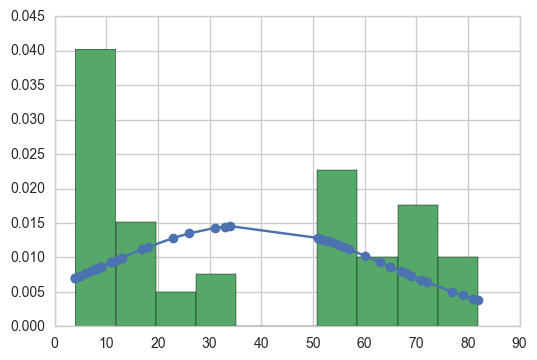

```python
histogram(csv_dic['Rate']).show()
```

##### 15. Plot the Math distribution

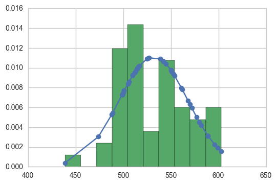

```python
histogram(csv_dic['Math']).show()
```

##### 16. Plot the Verbal distribution

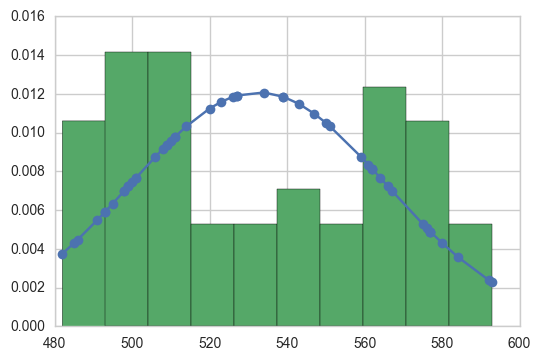

```python
histogram(csv_dic['Verbal']).show()
```

##### 17. What is the typical assumption for data distribution?

As visible in each of the above graphs Only in **Math** distribution seems **Normal** and all other distributions are not a **Normal** distribution

##### 18. Does that distribution hold true for our data?

In case of **Math** It meets our expectaion and **Verbal** does not

##### 19. Plot some scatterplots. **BONUS**: Use a PyPlot `figure` to present multiple plots at once.

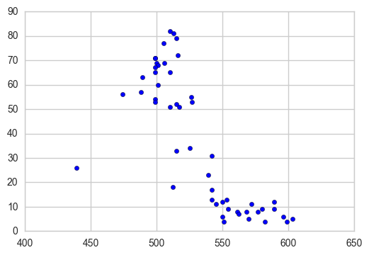

```python
plt.scatter(csv_dic['Math'], csv_dic['Rate'])
```

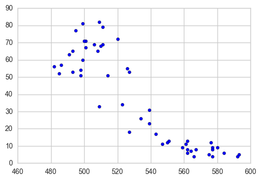

```python
plt.scatter(csv_dic['Verbal'], csv_dic['Rate'])
```

##### 20. Are there any interesting relationships to note?

As Above plots suggest we can assume the higher the **Rate** of participation the lower the average score would be and it is valid in both **Math** and **Verbal** tests

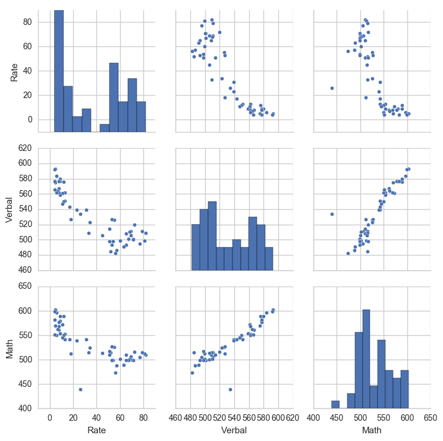

```python
st = sns.pairplot(pd.read_csv(sat_csv_path))
```

##### 21. Create box plots for each variable.

```python
figure1 = go.Box(
    x=csv_dic['Math'],
    name = "Math",
    boxpoints='all'
)
figure2 = go.Box(
    x=csv_dic['Verbal'],
    name = "Verbal",
    boxpoints='all'
)
data = [figure1, figure2]
py.iplot(data)
```

[interactive chart not shown]

##### BONUS: Using Tableau, create a heat map for each variable using a map of the US.

For the time being, create the visualization in Tableau and load the image inline within your notebook:

[figure not shown]

```python
df = pd.read_csv(sat_csv_path)
for col in df.columns:
    df[col] = df[col].astype(str)

scl = [[0.0, 'rgb(242,240,247)'],[0.2, 'rgb(218,218,235)'],[0.4, 'rgb(188,189,220)'],\
            [0.6, 'rgb(158,154,200)'],[0.8, 'rgb(117,107,177)'],[1.0, 'rgb(84,39,143)']]
df['text'] = df['State'] + '<br>' + 'Rate: ' + df['Rate'] + '<br>'+ 'Math: ' + df['Math'] + '<br>' + 'Verbal: ' + df['Verbal']
```

```python
def get_data(column, dataset, titl, state='State', tex='text',):
    data = [ dict(
            type='choropleth',
            colorscale = scl,
            autocolorscale = False,
            locations = dataset[state],
            z = dataset[column].astype(int),
            locationmode = 'USA-states',
            text = dataset[tex],
            marker = dict(
                line = dict (
                    color = 'rgb(255,255,255)',
                    width = 2
                ) ),
            colorbar = dict(
                title = titl)
            ) ]
    return data
def get_layout():
    layout = dict(
            title = '2001 US SAT Score',
            geo = dict(
                scope='usa',
                projection=dict( type='albers usa' ),
                showlakes = True,
                lakecolor = 'rgb(255, 255, 255)'),
                 )
    return layout
```

```python
fig = dict( data=get_data('Rate', df, 'Rate of Participation'), layout=get_layout() )
py.iplot( fig, filename='RateDistribution' )
```

[interactive chart not shown]

```python
fig = dict( data=get_data('Verbal', df, 'Verbal Score'), layout=get_layout() )
py.iplot( fig, filename='VerbalDistribution' )
```

[interactive chart not shown]

```python
fig = dict( data=get_data('Math', df, 'Math Score'), layout=get_layout() )
py.iplot( fig, filename='MathDistribution' )
```

[interactive chart not shown]